# homework_7_vo_ken

Ken Vo

March 19, 2019

```r
library(tidyverse)
library(mdsr)
library(ggpubr)
library(broom)
library(scales)
```

————————————— EXERCISE 1 ————————————

The glimpse command returns 1,460 observations and 81 columns.

```r
fl_pth_train <- "/home/me/Documents/Data Science Certificate Courses/Compscix-415-2/compscix-415-2-assignments/train.csv"
train <- read_csv(file=fl_pth_train)
glimpse(train)
```

```
## Observations: 1,460
## Variables: 81
## $ Id            <dbl> 1, 2, 3, 4, 5, 6, 7, 8, 9, 10, 11, 12, 13, 14, 15,…
## $ MSSubClass    <dbl> 60, 20, 60, 70, 60, 50, 20, 60, 50, 190, 20, 60, 2…
## $ MSZoning      <chr> "RL", "RL", "RL", "RL", "RL", "RL", "RL", "RL", "R…
## $ LotFrontage   <dbl> 65, 80, 68, 60, 84, 85, 75, NA, 51, 50, 70, 85, NA…
## $ LotArea       <dbl> 8450, 9600, 11250, 9550, 14260, 14115, 10084, 1038…
## $ Street        <chr> "Pave", "Pave", "Pave", "Pave", "Pave", "Pave", "P…
## $ Alley         <chr> NA, NA, NA, NA, NA, NA, NA, NA, NA, NA, NA, NA, NA…
## $ LotShape      <chr> "Reg", "Reg", "IR1", "IR1", "IR1", "IR1", "Reg", "…
## $ LandContour   <chr> "Lvl", "Lvl", "Lvl", "Lvl", "Lvl", "Lvl", "Lvl", "…
## $ Utilities     <chr> "AllPub", "AllPub", "AllPub", "AllPub", "AllPub", …
## $ LotConfig     <chr> "Inside", "FR2", "Inside", "Corner", "FR2", "Insid…
## $ LandSlope     <chr> "Gtl", "Gtl", "Gtl", "Gtl", "Gtl", "Gtl", "Gtl", "…
## $ Neighborhood  <chr> "CollgCr", "Veenker", "CollgCr", "Crawfor", "NoRid…
```

[output cut: 68 more lines]

————————————— EXERCISE 2 ————————————

Exercise 2 - Visualizing the distribution of SalePrice

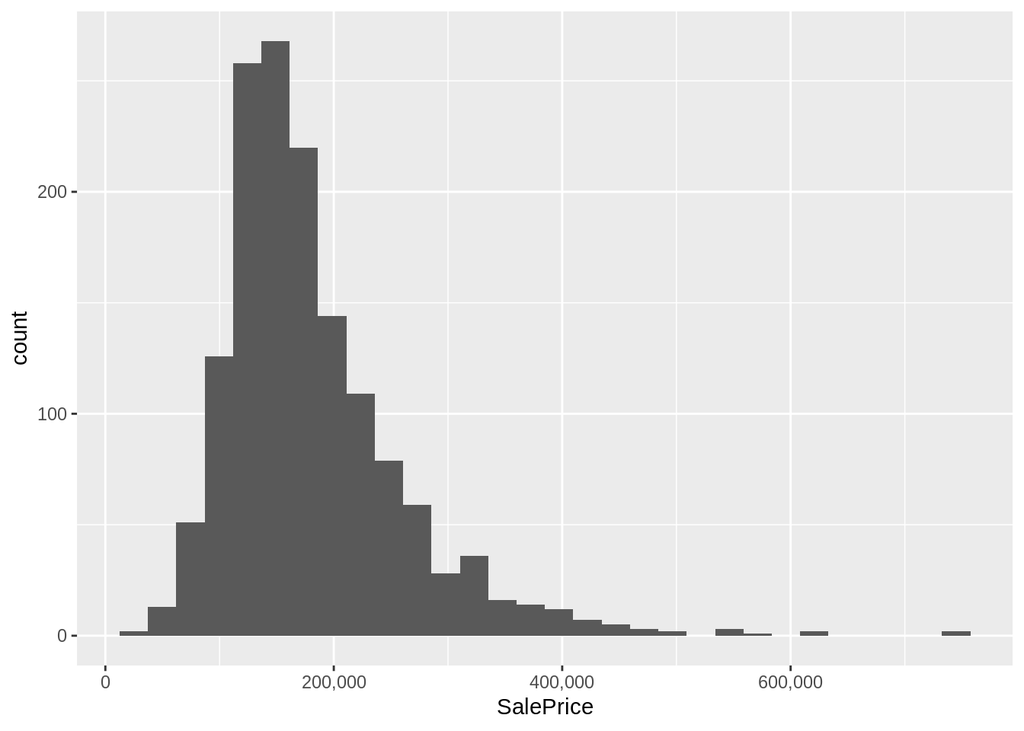

```r
ggplot(data=train)+
  geom_histogram(mapping=aes(x=SalePrice))+
  scale_x_continuous(labels=comma)
```

Exercise 2 - Visualizing SalePrice and Neighborhood

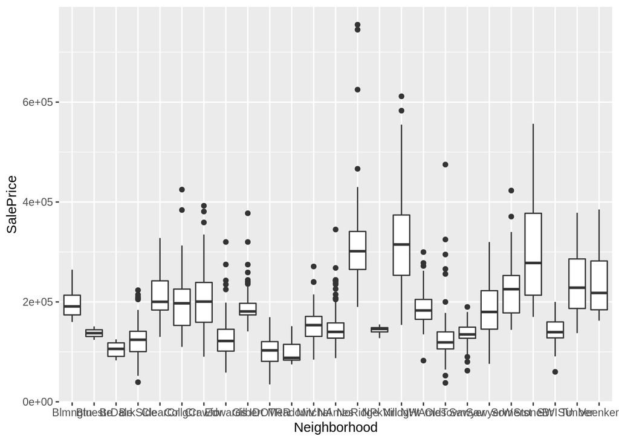

```r
ggplot(data = train, mapping = aes(x = Neighborhood, y = SalePrice)) +
  geom_boxplot()
```

Exercise 2 - Visualizing SalePrice and OverallQual

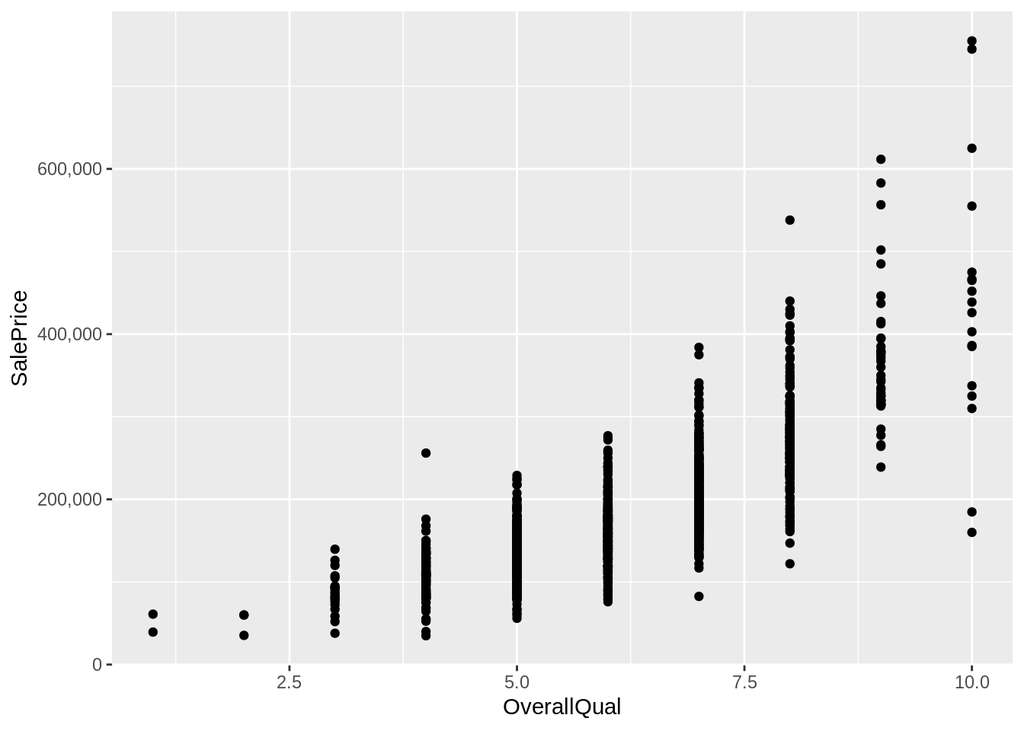

```r
ggplot(data = train) +
  geom_point( mapping = aes(x = OverallQual, y = SalePrice))+
  scale_y_continuous(labels=comma)
```

————————————— EXERCISE 3 ————————————

```r
saleprice_lm <- lm(formula = SalePrice ~ OverallQual, data = train)
summary(saleprice_lm)
```

```
##
## Call:
## lm(formula = SalePrice ~ OverallQual, data = train)
##
## Residuals:
##     Min      1Q  Median      3Q     Max
## -198152  -29409   -1845   21463  396848
##
## Coefficients:
##             Estimate Std. Error t value Pr(>|t|)
## (Intercept) -96206.1     5756.4  -16.71   <2e-16 ***
## OverallQual  45435.8      920.4   49.36   <2e-16 ***
## ---
## Signif. codes:  0 '***' 0.001 '**' 0.01 '*' 0.05 '.' 0.1 ' ' 1
##
## Residual standard error: 48620 on 1458 degrees of freedom
## Multiple R-squared:  0.6257, Adjusted R-squared:  0.6254
## F-statistic:  2437 on 1 and 1458 DF,  p-value: < 2.2e-16
```

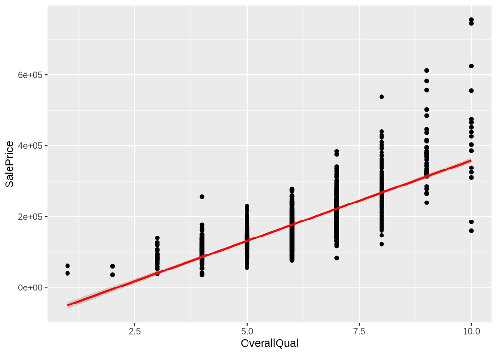

```r
ggplot(data=train, mapping=aes(x=OverallQual,y=SalePrice)) + geom_point() +
   stat_smooth(method = "lm", col = "red")
```

———————————— EXERCISE 4 ————————————

The overall relationship these features have on the target is that of an increase of the target. The relationship can be roughly estimated linearly. These are good features.

The intercepts and slopes are very different for GrLivArea and OverallQual. This means that the two features affect the SalePrice differently. The higher slope of OverallQual indicates a more dramatic rise in SalePrice compare to GrLivArea. The negative intercept of OverallQual does not make sense. Hence the model for OverallQual is not as robuts as the model for GrLivArea.

The three features, GrLivArea, OverallQual, and Neighborhood are practically significant. The model is good fit except for the fit to the Neighborhood.

Using GrLivArea as feature.

```r
saleprice_lm <- lm(formula = SalePrice ~ GrLivArea, data = train)
summary(saleprice_lm)
```

```
##
## Call:
## lm(formula = SalePrice ~ GrLivArea, data = train)
##
## Residuals:
##     Min      1Q  Median      3Q     Max
## -462999  -29800   -1124   21957  339832
##
## Coefficients:
##              Estimate Std. Error t value Pr(>|t|)
## (Intercept) 18569.026   4480.755   4.144 3.61e-05 ***
## GrLivArea     107.130      2.794  38.348  < 2e-16 ***
## ---
## Signif. codes:  0 '***' 0.001 '**' 0.01 '*' 0.05 '.' 0.1 ' ' 1
##
## Residual standard error: 56070 on 1458 degrees of freedom
## Multiple R-squared:  0.5021, Adjusted R-squared:  0.5018
## F-statistic:  1471 on 1 and 1458 DF,  p-value: < 2.2e-16
```

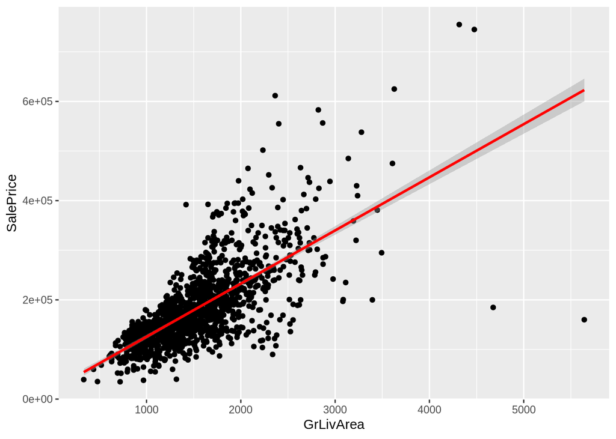

```r
ggplot(data=train, mapping=aes(x=GrLivArea,y=SalePrice)) + geom_point() +
   stat_smooth(method = "lm", col = "red")
```

Using OverallQual as feature.

```r
saleprice_lm <- lm(formula = SalePrice ~ OverallQual, data = train)
summary(saleprice_lm)
```

```
##
## Call:
## lm(formula = SalePrice ~ OverallQual, data = train)
##
## Residuals:
##     Min      1Q  Median      3Q     Max
## -198152  -29409   -1845   21463  396848
##
## Coefficients:
##             Estimate Std. Error t value Pr(>|t|)
## (Intercept) -96206.1     5756.4  -16.71   <2e-16 ***
## OverallQual  45435.8      920.4   49.36   <2e-16 ***
## ---
## Signif. codes:  0 '***' 0.001 '**' 0.01 '*' 0.05 '.' 0.1 ' ' 1
##
## Residual standard error: 48620 on 1458 degrees of freedom
## Multiple R-squared:  0.6257, Adjusted R-squared:  0.6254
## F-statistic:  2437 on 1 and 1458 DF,  p-value: < 2.2e-16
```

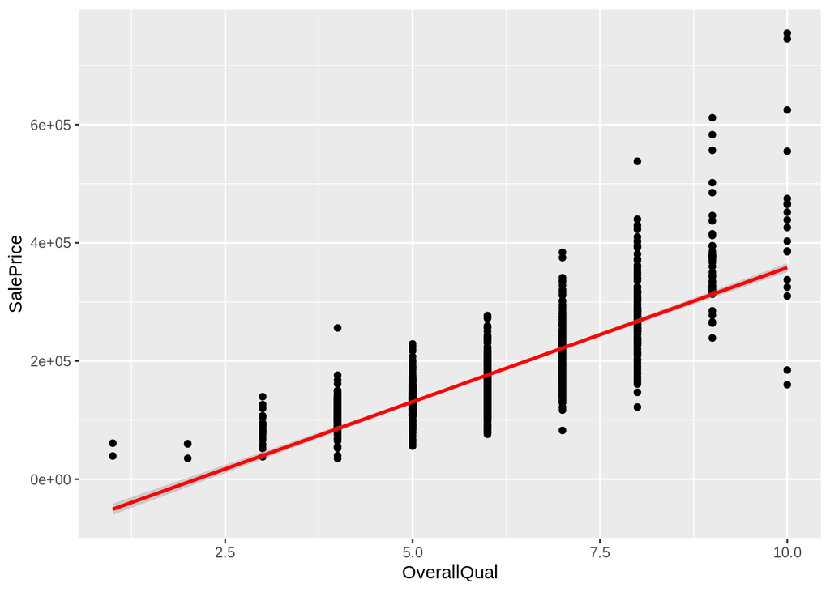

```r
ggplot(data=train, mapping=aes(x=OverallQual,y=SalePrice)) + geom_point() +
   stat_smooth(method = "lm", col = "red")
```

Using Neighborhood as feature.

```r
saleprice_lm <- lm(formula = SalePrice ~ Neighborhood, data = train)
summary(saleprice_lm)
```

```
##
## Call:
## lm(formula = SalePrice ~ Neighborhood, data = train)
##
## Residuals:
##     Min      1Q  Median      3Q     Max
## -162271  -27552   -5324   19685  419705
##
## Coefficients:
##                     Estimate Std. Error t value Pr(>|t|)
## (Intercept)           194871      13097  14.879  < 2e-16 ***
## NeighborhoodBlueste   -57371      40367  -1.421 0.155463
## NeighborhoodBrDale    -90377      18809  -4.805 1.71e-06 ***
## NeighborhoodBrkSide   -70037      14893  -4.703 2.81e-06 ***
## NeighborhoodClearCr    17694      16603   1.066 0.286721
## NeighborhoodCollgCr     3095      13819   0.224 0.822820
## NeighborhoodCrawfor    15754      15123   1.042 0.297712
## NeighborhoodEdwards   -66651      14166  -4.705 2.78e-06 ***
## NeighborhoodGilbert    -2016      14437  -0.140 0.888944
## NeighborhoodIDOTRR    -94747      15822  -5.988 2.67e-09 ***
## NeighborhoodMeadowV   -96294      18522  -5.199 2.29e-07 ***
## NeighborhoodMitchel   -38601      15200  -2.540 0.011204 *
## NeighborhoodNAmes     -49024      13582  -3.609 0.000318 ***
## NeighborhoodNoRidge   140424      15577   9.015  < 2e-16 ***
## NeighborhoodNPkVill   -52176      22260  -2.344 0.019217 *
## NeighborhoodNridgHt   121400      14470   8.390  < 2e-16 ***
## NeighborhoodNWAmes     -5821      14542  -0.400 0.689011
## NeighborhoodOldTown   -66646      14047  -4.744 2.30e-06 ***
## NeighborhoodSawyer    -58078      14523  -3.999 6.69e-05 ***
## NeighborhoodSawyerW    -8315      14864  -0.559 0.575974
## NeighborhoodSomerst    30509      14333   2.129 0.033456 *
## NeighborhoodStoneBr   115628      16975   6.812 1.42e-11 ***
## NeighborhoodSWISU     -52280      16975  -3.080 0.002111 **
## NeighborhoodTimber     47377      15756   3.007 0.002686 **
## NeighborhoodVeenker    43902      20895   2.101 0.035810 *
## ---
## Signif. codes:  0 '***' 0.001 '**' 0.01 '*' 0.05 '.' 0.1 ' ' 1
##
## Residual standard error: 54000 on 1435 degrees of freedom
## Multiple R-squared:  0.5456, Adjusted R-squared:  0.538
## F-statistic: 71.78 on 24 and 1435 DF,  p-value: < 2.2e-16
```

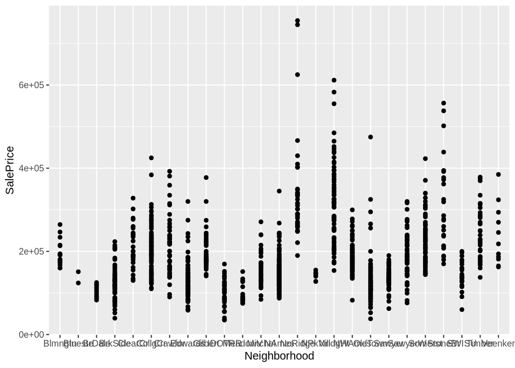

```r
ggplot(data=train, mapping=aes(x=Neighborhood,y=SalePrice)) + geom_point() +
   stat_smooth(method = "lm", col = "red")
```

————————————— EXERCISE 6 ————————————

The coefficient on x and the R-squared values do not change much from one run to another.

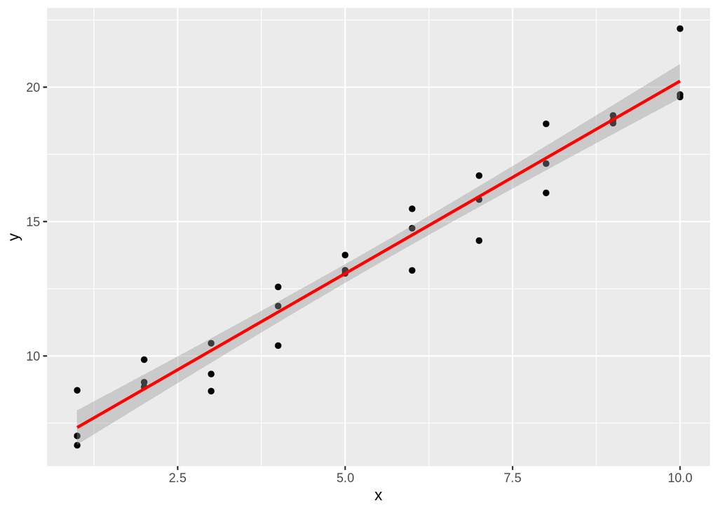

```r
sim1a <- tibble(
x = rep(1:10, each = 3),
y= x * 1.5 + 6 + rt(length(x), df = 2)
)

ggplot(data=sim1a, mapping=aes(x,y)) + geom_point() +
   stat_smooth(method = "lm", col = "red")
```

```r
sim1a_lm <- lm(formula = y ~ x, data = sim1a)
summary(sim1a_lm)
```

```
##
## Call:
## lm(formula = y ~ x, data = sim1a)
##
## Residuals:
##      Min       1Q   Median       3Q      Max
## -1.63944 -0.56892  0.03995  0.58312  1.95174
##
## Coefficients:
##             Estimate Std. Error t value Pr(>|t|)
## (Intercept)  5.90751    0.36252   16.30 8.08e-16 ***
## x            1.43188    0.05843   24.51  < 2e-16 ***
## ---
## Signif. codes:  0 '***' 0.001 '**' 0.01 '*' 0.05 '.' 0.1 ' ' 1
##
## Residual standard error: 0.9192 on 28 degrees of freedom
## Multiple R-squared:  0.9555, Adjusted R-squared:  0.9539
## F-statistic: 600.6 on 1 and 28 DF,  p-value: < 2.2e-16
```